# Approximation of the Distribution

Fang Guo

2020/3/22

Abstract

This report complete approximation of the distribution fuction of $N(0,1)$ by the Monte Carlo methods. By writing this report, i learn most common components of a single R Markdown document, like forming a table, math equation and so on.

# 1 Introduction

This report complete approximation of the distribution fuction of $N(0,1)$ by the Monte Carlo methods. By writing this report, i have learned a template in R Markdown. I know most of the basic syntax of writing a single R Markdown document.

The rest of this report is organised as follows: In Section 2 , i give some mathematical equations about this problem. The generation of tables and other R objects is dispalyed in Section 3. And a brief demonstration of a code chunk is gave in this Section. At last but not least, i give a brief explaination of resluts in last section.

# 2 Math Equations

In this problem, i consider approximation the distribution function of $N(0,1)$ ,
$$\begin{align}
\Phi(t) = \int_{-\infty}^t\frac{1}{\sqrt{{2\pi}}}e^
{(-y^2)/2} \,{\rm d}y,
\end{align}$$
by the Monte Carlo methods:
$$\begin{align}
\hat{\Phi}(t) = \frac{1}{n}\sum_{i=1}^n I(X_i \leq t),
\end{align}$$
where $X_i$ is a random sample from $N(0,1)$, and $I(.)$ is the indicator function.

# 3 Results

I experiment with the approximation at $n \in \lbrace10^2,10^3,10^4\rbrace$ at $t \in \lbrace0.0,0.67,0.84,1.28,1.65,2.32,2.58,3.09,3.72\rbrace$ to form a table. At the same time, the table include the true value for comparison. It can be generated by the following R code chunk. The resulting table is shown in table 3.1.

```r
t=c(0,0.67,0.84,1.28,1.65,2.32,2.58,3.09,3.72)
n=c(100,1000,10000)
p=matrix(0,nrow=9,ncol=3)
#a=0
for (i in 1:9)
  for(j in 1:3){
    #a=a+1
    num=rnorm(n[j],0,1)
    p[i,j]=mean(num<t[i])
    #print(a)
  }
rownames(p)<-t
colnames(p)<-n
true_value<-c(pnorm(0),pnorm(0.67),pnorm(0.84),pnorm(1.28),pnorm(1.65),
           pnorm(2.32),pnorm(2.58),pnorm(3.09),pnorm(3.72))
p<-cbind(p,true_value)
p<-round(p,digits=3)
#美化表格
library(knitr)
library(magrittr)
library(kableExtra)
kable(p, booktabs=TRUE, caption='The table of approximation results.') %>%
  kable_styling(bootstrap_options = "striped",full_width = F) %>%
 column_spec(1,bold=T)#full_width=F,不占满全屏
```

Table 3.1: The table of approximation results.

|  | 100 | 1000 | 10000 | true_value |
| --- | --- | --- | --- | --- |
| 0 | 0.58 | 0.500 | 0.497 | 0.500 |
| 0.67 | 0.69 | 0.751 | 0.745 | 0.749 |
| 0.84 | 0.84 | 0.804 | 0.798 | 0.800 |
| 1.28 | 0.90 | 0.887 | 0.902 | 0.900 |
| 1.65 | 0.97 | 0.948 | 0.948 | 0.951 |
| 2.32 | 0.99 | 0.996 | 0.992 | 0.990 |
| 2.58 | 1.00 | 0.994 | 0.995 | 0.995 |
| 3.09 | 1.00 | 0.998 | 0.999 | 0.999 |
| 3.72 | 1.00 | 1.000 | 1.000 | 1.000 |

Further, repeat the experiment 100 times. Draw box plots of the 100 approximation errors at each $t$ using ggplot2 for each $n$. Figure 3.1 is the resulting plot. Because the codes generated following box plots are too much, so it just show the part of codes. These code can generate the top three image. I just put other codes in another file. If you are interested in it. You can read it in the file named “code”.

```r
p1<-ggplot(data=plot_data,aes(y=V1,x=label1))+geom_boxplot(
  fill="thistle",colour="gray27")+
  labs(title="Boxplot of error at t=0, n=100",y="error",
       x=NULL)+theme(plot.title=element_text(size=13,hjust=0.5))
      #+theme_bw()-背景换为白色 ,theme(hjust)=0.5
p2<-ggplot(data=plot_data,aes(y=V2,x=label2))+geom_boxplot(
  fill="thistle",colour="gray27")+
  labs(title="Boxplot of error at t=0, n=1000",y="error",
       x=NULL)+theme(plot.title=element_text(size=13,hjust=0.5))
p3<-ggplot(data=plot_data,aes(y=V3,x=label3))+geom_boxplot(
  fill="thistle",colour="gray27")+
  labs(title="Boxplot of error at t=0, n=10000",y="error",
       x=NULL)+theme(plot.title=element_text(size=13,hjust=0.5))
g1<-multiplot(p1,p2,p3,cols=3)
```

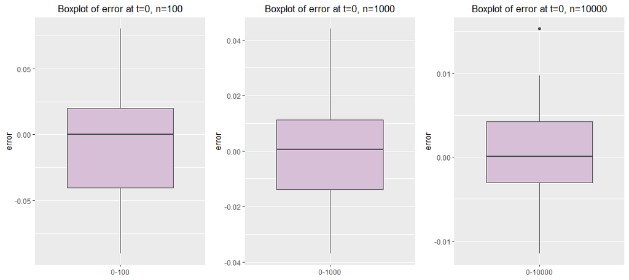

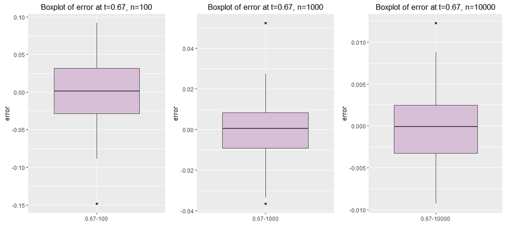

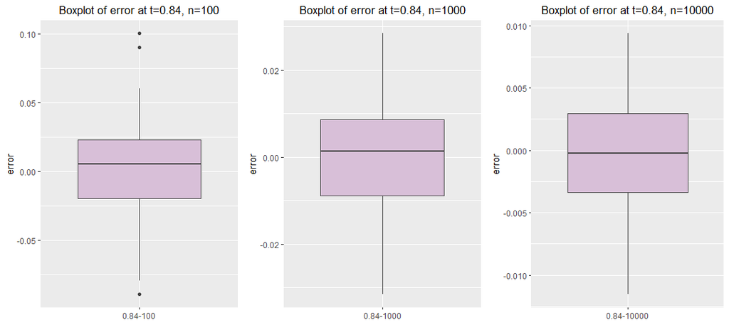

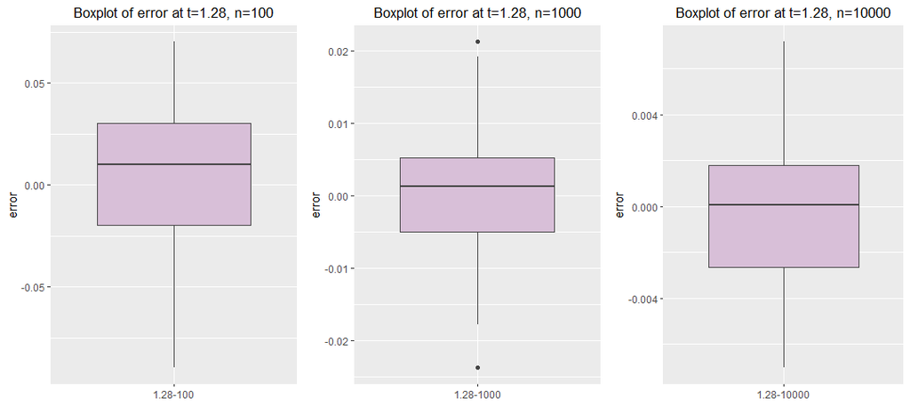

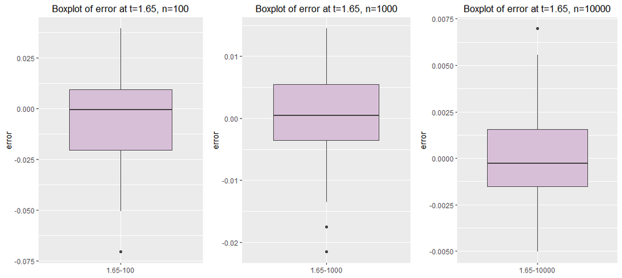

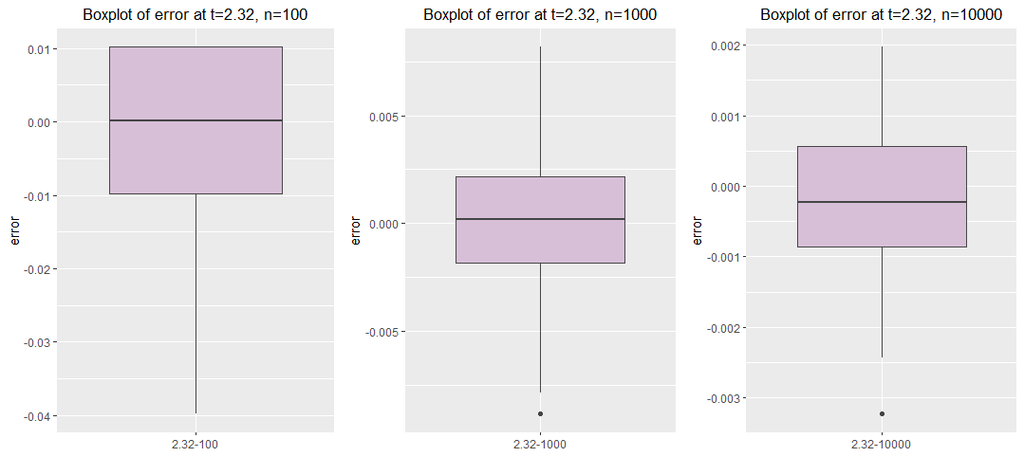

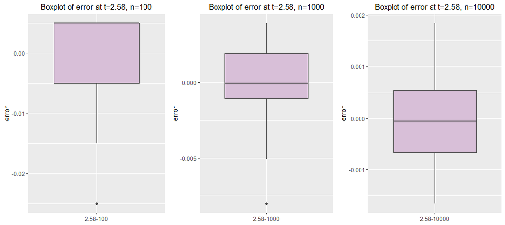

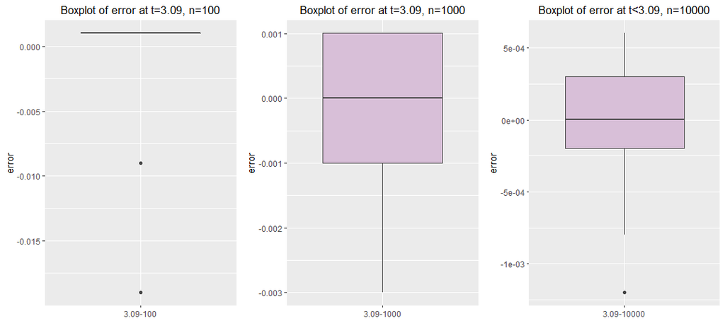

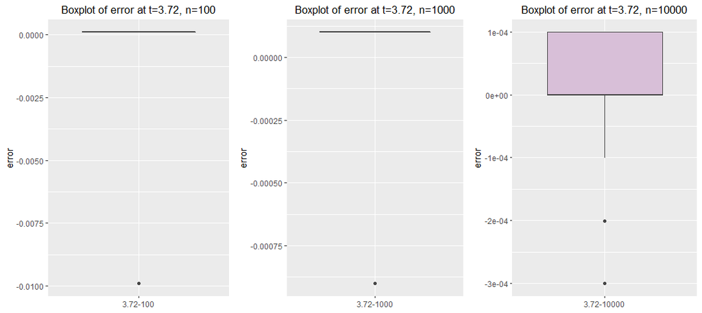

Figure 3.1: The boxplots of errors

```r
#out.width = '50%', fig.show = 'hold'为了使图形挨着显示
knitr::include_graphics(c("img/plot1(t=0).png","img/plot2(t=0.67).png",
                          "img/plot3(t=0.84).png","img/plot4(t=1.28).png",
                          "img/plot5(t=1.65).png","img/plot6(t=2.32).png",
                          "img/plot7(t=2.58).png","img/plot8(t=3.09).png",
                          "img/plot9(t=3.72).png"),dpi=1)
```

# 4 Explaination

In the section 3, i generete one table to describe the difference between approximation and true value. It shows the error is decreasing as the number of samples become larger. And in figure 3.1, this inclusion is proved once again. At the same time, we could see when number of samples expand, the extremum is decreasing. Especially, when t=3.09, n=100 or t=3.72, n=100, 1000, the errors are almost 0.

# 5 Acknowledgment

I would like to thank all teachers, especially Professor Jun Yan. Without this class, i would not to learn this thing by myself.